# Exercise 2: Reusing analysis results

Sometimes plans change

## Scenario

Imagine the following scenario: we have performed our analysis, produced our Kaplan-Meier (KM) plot, written up our work, finalised and completed the submission.

Then comes a request to publish the same analysis in a different venue, but with the following comments:

> Please can you modify your KM plot to meet the current recommendations of the journal as spelled out by Morris et al. (Morris et al. 2019) … and we need the corrected version by tomorrow!!!

Specifically, the request is to reformat the KM plot to mirror the following example to meet the publication criteria.

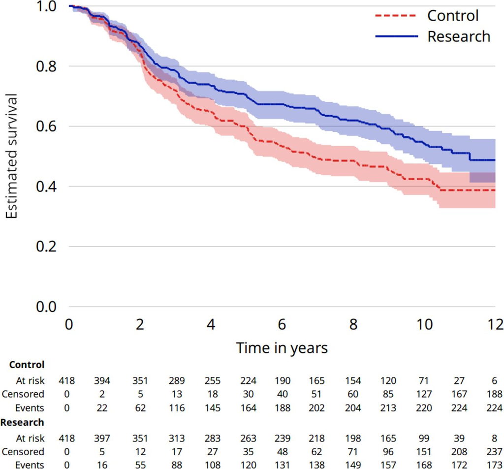

### Typical approach

This is a common scenario. We may want to use the same analysis in a variety of venues. Each venue may have a different set of requirements, a different audience, and so on. This implicitly means that the output must be reformatted to meet those specifications. For example, for a printed publication, a CSR appendix, a shiny app, or for an interactive document.

We want to avoid repeating the same analysis by keeping the single source of truth and only reformat it. For example, we may have a new or separate team working on this request. They may not have the context of the analysis, so they try to recreate it with good intent and change specific settings.

Below is a possible scenario where in recreating the analysis, the statistician uses settings in `Surv()` to estimate confidence intervals with the *log-log* method using a *robust* variance estimator. Although an appropriate approach, this deviates from the original statistical analysis plan. This increases the risk of presenting different numbers, creating confusion.

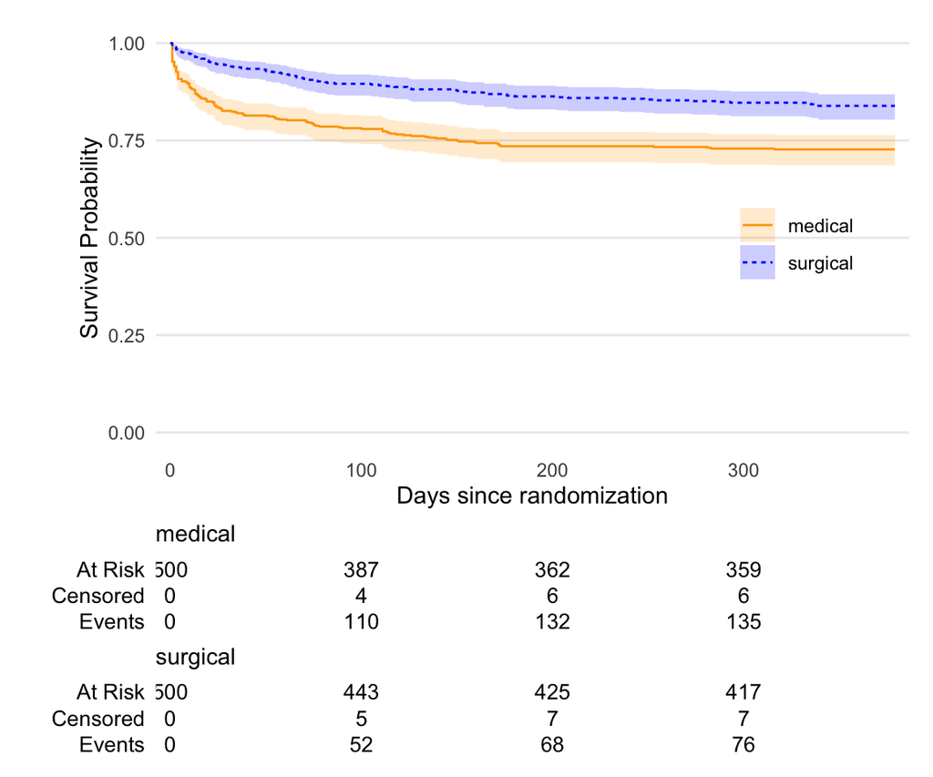

```r
adtte <- readRDS(here::here("data", "adtte.rds"))

redone_analysis_plot <- survfit2(Surv(AVAL, 1 - CNSR) ~ TRTP,
  data = adtte,
  conf.type = "log-log", robust = TRUE
) |>
  ggsurvfit(linetype_aes = TRUE) +
  add_confidence_interval() +
  add_risktable(
    risktable_stats = c("n.risk", "cum.censor", "cum.event")
  ) +
  theme_ggsurvfit_KMunicate() +
  scale_y_continuous(limits = c(0, 1)) +
  scale_x_continuous(expand = c(0.02, 0)) +
  theme(legend.position = c(0.85, 0.5)) +
  scale_color_manual(values = c("orange", "blue")) +
  scale_fill_manual(values = c("orange", "blue")) +
  xlab("Days since randomization")

redone_analysis_plot
```

### Instead, how could we proceed?

Think back to the previous exercise.

- What information have we stored according to the data model?
- Can the additional information required be computed without re-running the analysis?
- Is there any information missing?

Let’s inspect the previous tables in the context of this new request.

```r
survival_ard <- readRDS(file = here("data", "survival_ard.rds"))
glimpse(survival_ard)
```

```
Rows: 1,584
Columns: 5
$ id          <chr> "ARD01", "ARD01", "ARD01", "ARD01", "ARD01", "ARD01", "ARD…
$ description <chr> "survival 01", "survival 01", "survival 01", "survival 01"…
$ strata      <chr> "medical", "medical", "medical", "medical", "medical", "me…
$ name        <chr> "time", "n_risk", "n_event", "n_censor", "estimate", "std_…
$ value       <dbl> 0.00000000, 500.00000000, 0.00000000, 0.00000000, 1.000000…
```

Do we have all the information we require? **Yes!**

We have the upper and lower confidence limits, the number at risk, number of events, and the censoring information.

## Reusing the analysis results

We can continue with updating the plot we made on the previous exercise.

```r
outputs <- readRDS(file = here("data", "outputs.rds"))

title <- outputs |>
  filter(type == "title")

xlab <- outputs |>
  filter(type == "xlab")

ylab <- outputs |>
  filter(type == "ylab")

legend <- outputs |>
  filter(type == "legend")

legend_colors <- str_split(legend$color, pattern = ", ", simplify = T) |>
  str_split(pattern = " = ", simplify = T)


widen_survival_ard <- survival_ard |>
  pivot_wider(names_from = "name",
              values_from = "value",
              values_fn = list) |>
  unnest(cols = everything())

plot_original <-
  widen_survival_ard |>
  ggplot(aes(x = time, y = estimate, ymin = ci_lower, ymax = ci_upper)) +
  geom_step(aes(colour = strata)) +
  theme(
    legend.position = legend$location,
    legend.key = element_rect(fill = "white"),
    panel.background = element_rect(fill = "white"),
    panel.grid.major = element_line(
      linewidth = 0.3, linetype = "solid",
      colour = "grey"
    ),
    panel.grid.minor = element_line(
      linewidth = 0.1, linetype = "solid",
      colour = "grey"
    ),
    plot.title = element_text(face = title$weight),
    axis.title.y = element_text(face = ylab$weight),
    axis.title.x = element_text(face = xlab$weight)
  ) +
  expand_limits(x = 0, y = 0) +
  ylab(ylab$text) +
  xlab(xlab$text) +
  ggtitle(title$text) +
  guides(color = guide_legend(title = legend$text)) +
  scale_color_manual(
    limits = legend_colors[, 1],
    values = legend_colors[, 2]
  )
```

### Adding confidence bands

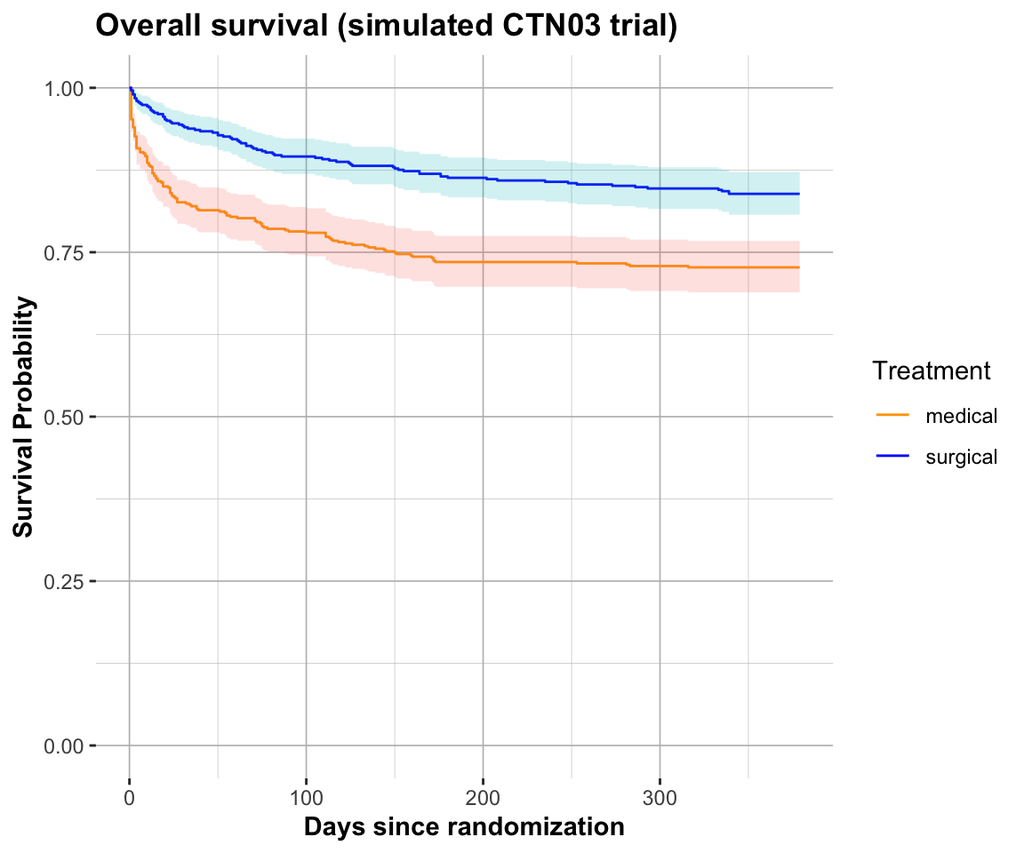

```r
plot_reformat1 <- plot_original +
  geom_ribbon(
    stat = "stepribbon", alpha = 0.2,
    aes(fill = strata), show.legend = FALSE
  )


plot_reformat1
```

### Adding the table below the plot

To add the table with information at specific time points we need to calculate the cumulative sum for the number of events. This requires a bit more code but, assuming the use of a data model, you can also build functions to perform these tasks.

```r
# Calculate cumulative number of events and censoring. Then, reformat table to
#  easily extract the respective values at a specific time
ard_reformatted <- widen_survival_ard |>
  group_by(strata) |>
  arrange(time) |>
  mutate(
    cum_event = cumsum(n_event),
    cum_censor = cumsum(n_censor)
  ) |>
  ungroup() |>
  pivot_longer(
    cols = c("cum_event", "cum_censor", "n_risk"),
    names_to = "type",
    values_to = "value"
  )

# Create a function to extract the number of events and censoring at a
#  given time
extract_values <- function(data, time_break, stratum) {
  times <- data |>
    filter(strata == stratum) |>
    pull(time)

  times[which.min(abs(times - time_break))]
}

# Specify the times of interest
time_breaks <- c(0, 100, 200, 300)

# Extract values for each strata
marks_surgical <- map_vec(
  .x = time_breaks,
  .f = extract_values,
  data = ard_reformatted,
  stratum = "surgical"
)

marks_medical <- map_vec(
  .x = time_breaks,
  .f = extract_values,
  data = ard_reformatted,
  stratum = "medical"
)

# Prepare data to create the tables
data_surgical <- ard_reformatted |>
  filter(
    strata == "surgical",
    time %in% marks_surgical
  )

data_medical <- ard_reformatted |>
  filter(
    strata == "medical",
    time %in% marks_medical
  )

# Create a function to produce the tables
make_table <- function(data, breaks) {
  n_types <- length(unique(data$type))

  prep_data <- data |>
    select(time, type, value) |>
    arrange(type) |>
    mutate(time = rep(breaks, n_types)) |>
    mutate(type = case_when(
      type == "n_risk" ~ "At risk",
      type == "cum_event" ~ "Event",
      type == "cum_censor" ~ "Censored"
    ))
  prep_data |>
    ggplot(aes(x = time, y = type, label = value)) +
    geom_text(size = 3) +
    theme_minimal() +
    scale_x_continuous(minor_breaks = NULL) +
    theme(
      panel.grid.major = element_blank(),
      panel.grid.minor = element_blank(),
      legend.position = "none",
      panel.border = element_blank(),
      axis.text.x = element_blank(),
      axis.ticks = element_blank(),
      plot.margin = unit(c(0.5, 5, 0, 0.5), "cm"),
      plot.title = element_text(size = 10, face = "bold", hjust = -0.1)
    ) +
    xlab(NULL) +
    ylab(NULL)
}
```

Now, we can create the tables that will go below the plot followed by arranging them accordingly.

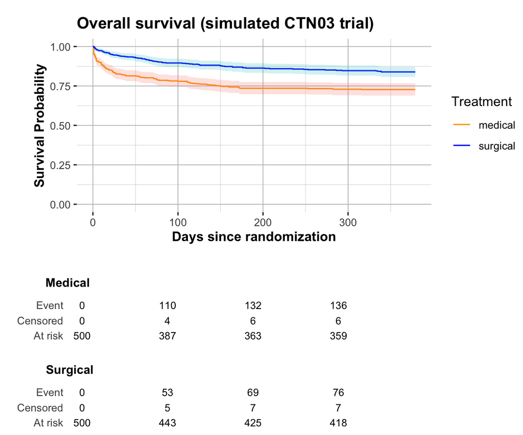

```r
# Create tables
table_medical <- make_table(data_medical, breaks = time_breaks) +
  ggtitle("Medical")

table_surgical <- make_table(data_surgical, breaks = time_breaks) +
  ggtitle("Surgical")

# Slight adjustment to more or less align the plot and tables
plot_reformat2 <- plot_reformat1 +
  theme(plot.margin = unit(c(0.5, 0, 0.5, 1), "cm"))

requested_plot <- ggarrange(plot_reformat2,
  table_medical,
  table_surgical,
  nrow = 3, heights = c(3, 1, 1)
)

requested_plot
```

### An update to the request

An additional request has arrived:

> Great plot. Thanks for your work! But… can you please add the censoring information to the lines instead of having it in the table. I prefer it like that. ASAP please!!!

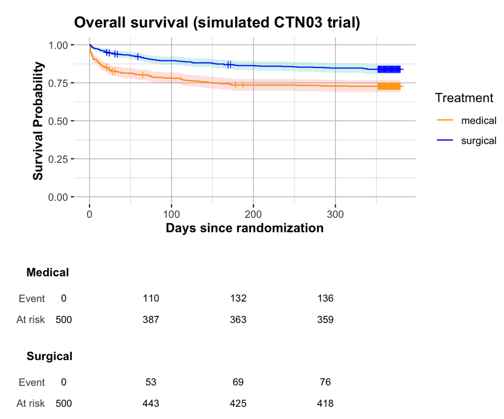

```r
# Add the censoring to the lines
plot_reformat4 <-
  plot_reformat1 +
  geom_point(
    data = filter(widen_survival_ard, n_censor > 0),
    aes(x = time, y = estimate, color = strata),
    shape = 3,
    show.legend = FALSE
  )

# Remove the censoring information from the tables
data_medical_upd <- data_medical |>
  filter(type != "cum_censor")

data_surgical_upd <- data_surgical  |>
  filter(type != "cum_censor")

table_medical_upd <- make_table(data_medical_upd, breaks = time_breaks) +
  ggtitle("Medical")

table_surgical_upd <- make_table(data_surgical_upd, breaks = time_breaks) +
  ggtitle("Surgical")

# Combine plot and tables
plot_reformat5 <- plot_reformat4 +
  theme(plot.margin = unit(c(0.5, 0, 0.5, 1), "cm"))

requested_plot2 <- ggarrange(plot_reformat5,
  table_medical_upd,
  table_surgical_upd,
  nrow = 3, heights = c(3, 1, 1)
)

requested_plot2
```

## Additional (take-home) tasks and questions

1. How would you calculate the median survival using the ARD?
2. Create a set of functions designed to work with the data following the ARDM. For example, one to create an interactive table and another a plot only using the stored information.
3. Add additional survival analyses. Can you perform a meta-analysis using the information stored? What is missing?

## References

Morris, Tim P, Christopher I Jarvis, William Cragg, Patrick P J Phillips, Babak Choodari-Oskooei, and Matthew R Sydes. 2019. “Proposals on Kaplanmeier Plots in Medical Research and a Survey of Stakeholder Views: KMunicate.” *BMJ Open* 9 (9). https://doi.org/10.1136/bmjopen-2019-030215.